# First Round Plots and Analysis

Christina Maimone

06 April, 2017

# Prelim

```r
library(stringr)
library(matrixStats)
library(dplyr)
library(ggplot2)
library(scales)
library(ggthemes)
library(DT)
library(knitr)
library(tidyr)
```

## Data

Data was created first in other files: * placement_cities_census.Rmd * population_data.Rmd

```r
load("arrivalsdata.RData")
load("census_population_data.RData")
```

# Basics

## Notes

For matching cities in the resettled data to census places, a Metro or Micropolitan area was used where one could be identified. For the few small cities outside of these aggregate regions, a Census “place” is used, followed by a “country subdivision” if even a place was too large to define the area. All of these different census geographies are combined below.

## How many resettled refugees?

Overall:

```r
sum(arrivals$city_nationality_total)
```

```
## [1] 894149
```

By year:

```r
arrivals %>% group_by(year) %>% summarize(count=sum(city_nationality_total)) %>% arrange(year) %>% datatable(rownames=FALSE, options = list(dom = 't', pageLength=20), caption="Total Resettled Refugees by Year")
```

| year | count |
| --- | --- |
| 2002 | 30289 |
| 2003 | 32235 |
| 2004 | 56355 |
| 2005 | 51904 |
| 2006 | 39552 |
| 2007 | 47753 |
| 2008 | 64734 |
| 2009 | 79938 |
| 2010 | 71362 |
| 2011 | 51458 |

[output cut: 5 more lines]

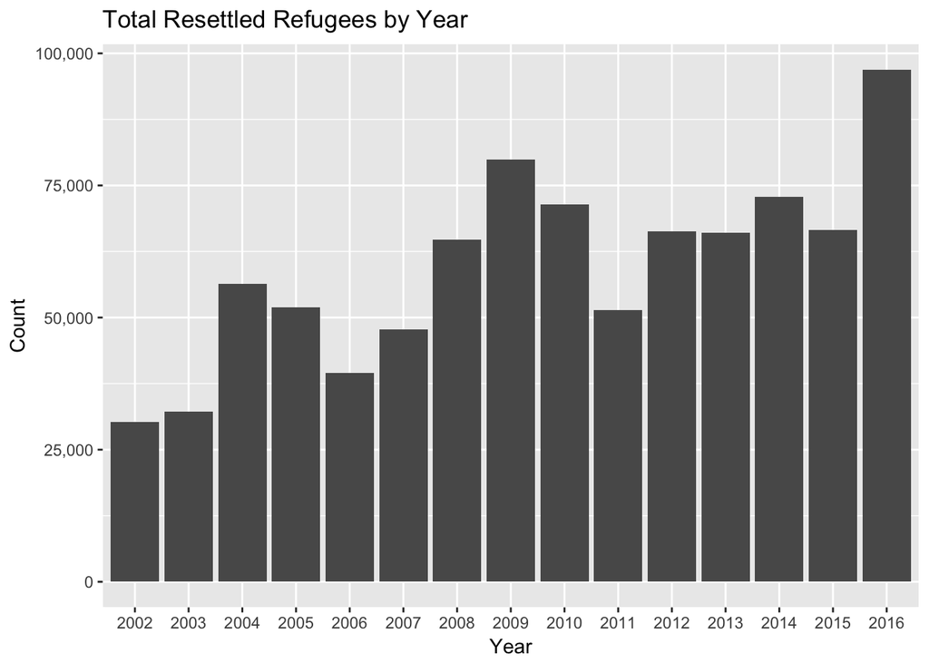

```r
arrivals %>% group_by(year) %>% summarize(count=sum(city_nationality_total)) %>% ggplot(aes(y=count, x=year))+geom_bar(stat="identity")+ggtitle("Total Resettled Refugees by Year")+ylab("Count")+xlab("Year")+scale_y_continuous(labels=comma)
```

## How many places couldn’t be identified?

I matched the cities in the refugee resettlement data to Census geographical definitions using a combination of name matching, geocoding to lat/long coordinates, and manual correction of typos/bad data. Nearly all places were matched. The matching is unlikely to be 100% accurate, but it should be very good. A few places couldn’t be matched, including cases where the city entered is the same as the state (some of these are theoretically cities, like Ohio City, but it’s too hard to know), or the name is too vague:

```r
filter(arrivals, is.na(unit)) %>% group_by(city, state) %>% summarize(count=sum(city_nationality_total)) %>% datatable(rownames=FALSE)
```

| city | state | count |
| --- | --- | --- |
| Beaver Wood | North Carolina | 1 |
| Chester Hills | Michigan | 2 |
| Colorado | Colorado | 5 |
| Decatur | Colorado | 1 |
| Grandon | Arizona | 2 |
| Green City | Idaho | 2 |
| Lake Hopatcong | New Jersey | 7 |
| New Smyrna Beach | Florida | 2 |
| North | California | 1 |
| Ohio | Ohio | 1 |

[output cut: 5 more lines]

## Where did the most refugees go?

```r
arrivals %>%
  group_by(geoname) %>%
  summarize(count=sum(city_nationality_total)) %>%
  arrange(desc(count)) %>%
  head(100) %>%
  datatable(rownames=FALSE, caption="100 Areas with Most Resettled Refugees, 2002-2016", colnames=c("Metro Area", "Count"))
```

| Metro Area | Count |
| --- | --- |
| Minneapolis-St. Paul-Bloomington, MN-WI | 35747 |
| Atlanta-Sandy Springs-Roswell, GA | 34436 |
| Dallas-Fort Worth-Arlington, TX | 33159 |
| Los Angeles-Long Beach-Anaheim, CA | 32039 |
| San Diego-Carlsbad, CA | 31043 |
| Phoenix-Mesa-Scottsdale, AZ | 28550 |
| Seattle-Tacoma-Bellevue, WA | 27070 |
| Chicago-Naperville-Elgin, IL-IN-WI | 25344 |
| Houston-The Woodlands-Sugar Land, TX | 25036 |
| Miami-Fort Lauderdale-West Palm Beach, FL | 22118 |

[output cut: 90 more lines]

## Which places had the most refugees as a percentage of population?

```r
totalresettled<-arrivals %>% mutate(place=ifelse(unit=='cbsa',geoname, paste(geoname, statecode, sep=", "))) %>% group_by(unit, geoid, place) %>% summarize(count=sum(city_nationality_total))
totalresettled<-mutate(totalresettled, population2015=ifelse(unit=="cbsa",
                                                             pop_cbsa$acs2015[match(geoid, pop_cbsa$msa)],
                                                             ifelse(unit=="place",
                                                             pop_places$acs2015[match(geoid, pop_places$place)],
                                                             ifelse(unit=="cosub",
                                                             pop_cosub$acs2015[match(geoid, pop_cosub$countysubdivision)],NA)))) %>% ungroup()
```

```r
totalresettled %>%
  mutate(prop=round(count/population2015, 2)) %>%
  arrange(desc(prop)) %>%
  select(place, count, population2015, prop) %>%
  head(100) %>%
  datatable(rownames=FALSE, caption="100 Areas with Highest Ratio of Resettled Refugees to Population", colnames=c("Census Geography","Refugee Count 2002-2016", "Population 2015","Ratio"))
```

| Census Geography | Refugee Count 2002-2016 | Population 2015 | Ratio |
| --- | --- | --- | --- |
| Shelby village, MI | 244 | 1908 | 0.13 |
| Huron, SD | 820 | 18168 | 0.05 |
| Delta Junction city, AK | 52 | 1045 | 0.05 |
| Curtiss village, WI | 14 | 319 | 0.04 |
| Bowling Green, KY | 4178 | 164245 | 0.03 |
| Twin Falls, ID | 3246 | 102657 | 0.03 |
| Moorefield town, WV | 86 | 2814 | 0.03 |
| Amarillo, TX | 5571 | 259216 | 0.02 |
| Burlington-South Burlington, VT | 3977 | 215081 | 0.02 |
| Concord, NH | 3137 | 147262 | 0.02 |

[output cut: 90 more lines]

Some small places, as expected, but also some sizeable ones.

# Size of Resettlment Cities

NOTE: population data is using 5-year estimates from the American Community Survey. This is necessary to get data for smaller places. All population figures are labeled according to the end year of the 5 year window. So, for example, 2015 population data below is the 2011-2015 ACS estimate.

## What size cities were refugees resettled to?

Group census places by their population

```r
totalresettled$citygroup<-cut(totalresettled$population2015,
                              breaks=c(0,10000,50000,100000,250000,500000,1000000,2000000,5000000,20000000),
                              right=FALSE,
                              labels=c("<10k", "10k-50k", "50k-100k", "100k-250k","250k-500k","500k-1m","1m-2m","2m-5m",">5m"))
```

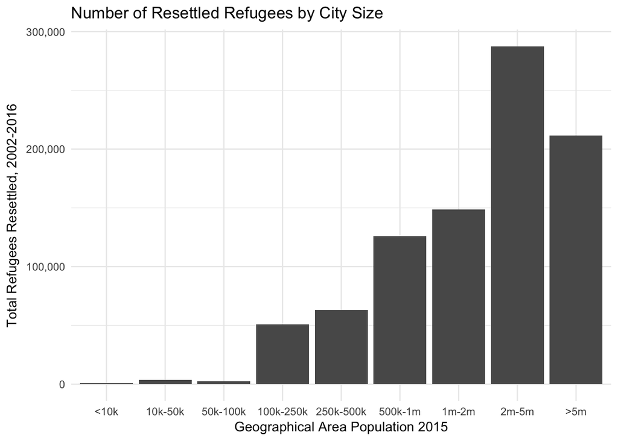

```r
totalresettled %>% filter(!is.na(citygroup)) %>% group_by(citygroup) %>% summarize(rcount=sum(count)) %>% ggplot(aes(x=citygroup, y=rcount))+geom_bar(stat="identity")+ggtitle("Number of Resettled Refugees by City Size")+xlab("Geographical Area Population 2015")+ylab("Total Refugees Resettled, 2002-2016")+scale_y_continuous(labels=comma)+theme_minimal()
```

So most refugees do go to large metro areas, but…has this pattern changed over time?

## Is the pattern of refugee resettlement, wrt city size, changing?

We’ll compute still using the 2015 population figures to keep cities from moving between categories.

```r
yearlyresettled<-arrivals %>% mutate(place=ifelse(unit=='cbsa',geoname, paste(geoname, statecode, sep=", "))) %>% group_by(unit, geoid, place, year) %>% summarize(count=sum(city_nationality_total))
yearlyresettled<-mutate(yearlyresettled, population2015=ifelse(unit=="cbsa",
                                                             pop_cbsa$acs2015[match(geoid, pop_cbsa$msa)],
                                                             ifelse(unit=="place",
                                                             pop_places$acs2015[match(geoid, pop_places$place)],
                                                             ifelse(unit=="cosub",
                                                             pop_cosub$acs2015[match(geoid, pop_cosub$countysubdivision)],NA)))) %>% ungroup()
yearlyresettled$citygroup<-cut(yearlyresettled$population2015,
                              breaks=c(0,10000,50000,100000,250000,500000,1000000,2000000,5000000,20000000),
                              right=FALSE,
                              labels=c("<10k", "10k-50k", "50k-100k", "100k-250k","250k-500k","500k-1m","1m-2m","2m-5m",">5m"))
```

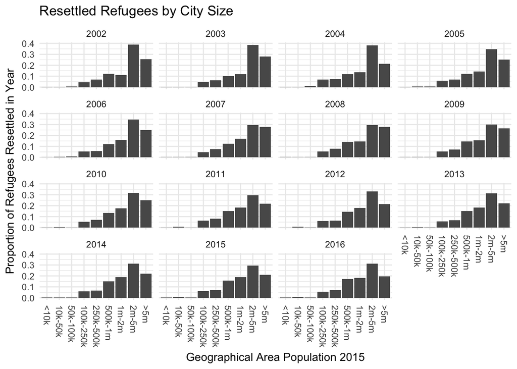

```r
yearlyresettled %>% filter(!is.na(citygroup)) %>% group_by(year) %>% mutate(yeartotal=sum(count)) %>% ungroup() %>% group_by(citygroup, year) %>% summarize(rcount=sum(count), prop=rcount/yeartotal[1]) %>% ggplot(aes(x=citygroup, y=prop))+geom_bar(stat="identity")+ggtitle("Resettled Refugees by City Size")+facet_wrap(~year)+xlab("Geographical Area Population 2015")+ylab("Proportion of Refugees Resettled in Year")+theme_minimal()+theme(axis.text.x = element_text(angle = -90, hjust=0, vjust=.5))
```

It appears that resettlement is shifting a bit toward slightly smaller cities. Let’s compute a mean and median city size over time. We’ll compute still using the 2015 population figures to avoid having their be an over time increase in the figures just from overall population growth.

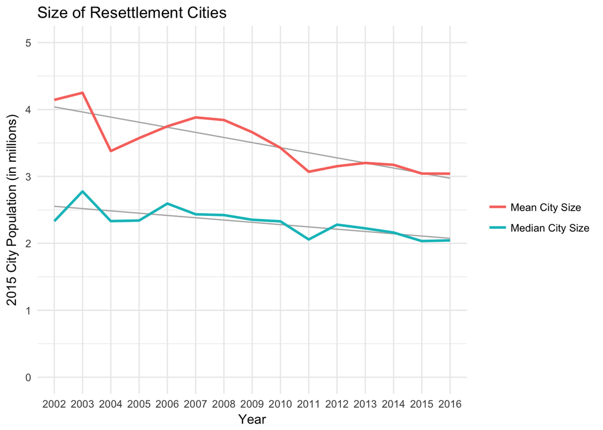

```r
yearlyresettled %>% group_by(year) %>%
  summarize(yearmedian=weightedMedian(population2015, count, na.rm=TRUE), yearmean=weightedMean(population2015, count, na.rm=TRUE)) %>%
  gather(measure, value, yearmedian, yearmean) %>%
  ggplot(aes(x=year, y=value, group=measure, color=measure))+
  geom_smooth(method='lm',formula=y~x, se=FALSE, size=.5, color="gray70")+geom_line(size=1)+
  scale_color_discrete(labels=c("Mean City Size","Median City Size"), name="")+
  labs(title="Size of Resettlement Cities", x="Year", y="2015 City Population (in millions)")+
  scale_y_continuous(labels=function(x){x/1000000}, limits=c(0,5000000))+
  theme_minimal()
```

## Just looking at small-ish places

Proportion to areas with population < 100,000 over time. Yearly proportions are less than 2%

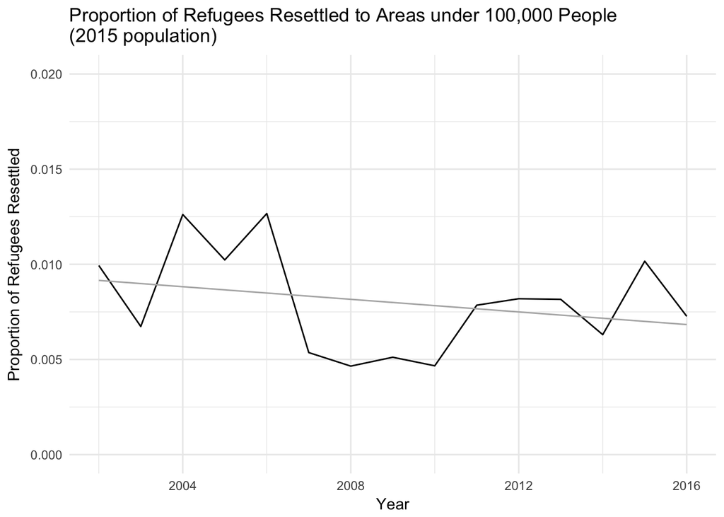

```r
yearlyresettled<-yearlyresettled %>% group_by(year) %>% mutate(yeartotal=sum(count,na.rm=T))
yearlyresettled %>% filter(population2015<100000) %>% group_by(year) %>% summarize(small=sum(count), prop=small/yeartotal[1]) %>% ggplot(aes(y=prop, x=as.numeric(as.character(year))))+geom_line()+geom_smooth(method='lm',formula=y~x, se=FALSE, size=.5, color="gray70")+labs(title="Proportion of Refugees Resettled to Areas under 100,000 People\n(2015 population)", x="Year", y="Proportion of Refugees Resettled")+ylim(0,0.02)+theme_minimal()
```

No real trend here – if anything, it’s decreasing. How about mid-sized cities?

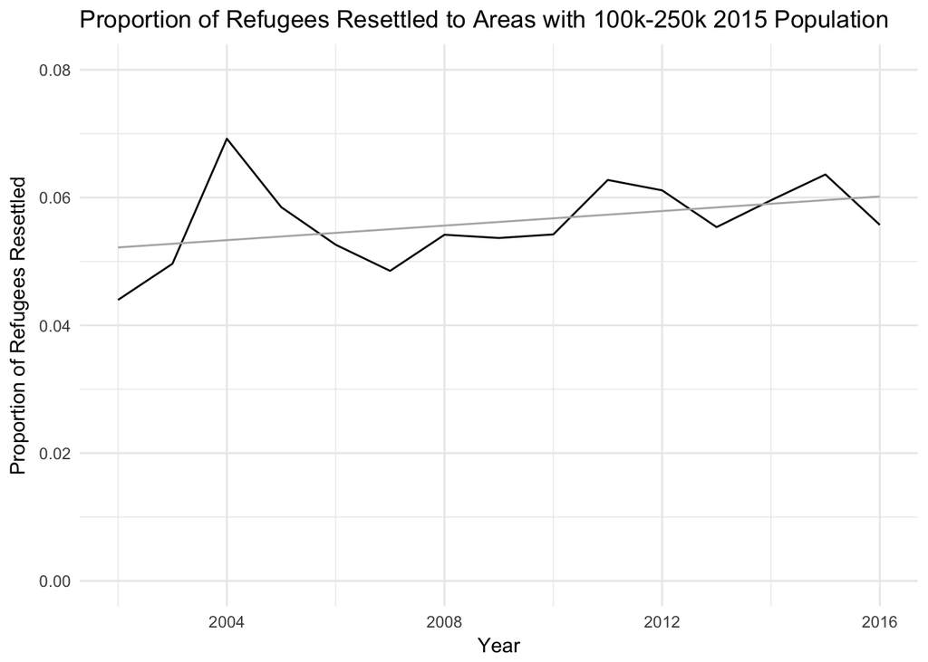

```r
yearlyresettled %>% filter(citygroup=="100k-250k") %>% group_by(year) %>% summarize(small=sum(count), prop=small/yeartotal[1]) %>% ggplot(aes(y=prop, x=as.numeric(as.character(year))))+geom_line()+labs(title="Proportion of Refugees Resettled to Areas with 100k-250k 2015 Population", x="Year", y="Proportion of Refugees Resettled")+ylim(0,0.08)+geom_smooth(method='lm',formula=y~x, se=FALSE, size=.5, color="gray70")+theme_minimal()
```

Slight increase here. Expand to cities 100-500k:

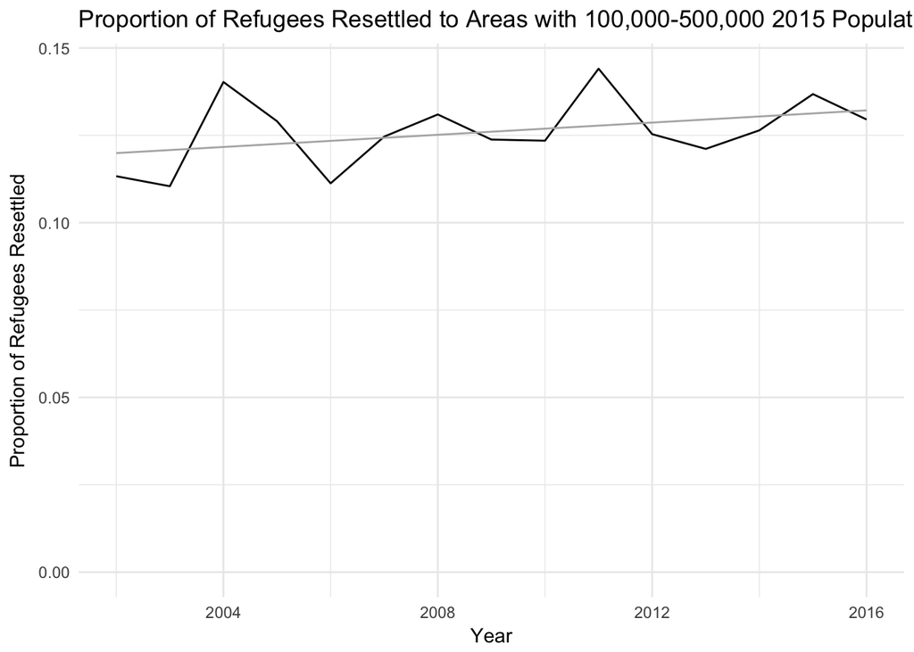

```r
yearlyresettled %>% filter(citygroup=="100k-250k"|citygroup=="250k-500k") %>% group_by(year) %>% summarize(small=sum(count), prop=small/yeartotal[1]) %>% ggplot(aes(y=prop, x=as.numeric(as.character(year))))+geom_line()+labs(title="Proportion of Refugees Resettled to Areas with 100,000-500,000 2015 Population", x="Year", y="Proportion of Refugees Resettled")+ylim(0,NA)+geom_smooth(method='lm',formula=y~x, se=FALSE, size=.5, color="gray70")+theme_minimal()
```

Still trending up. All of the categories together on a line chart?

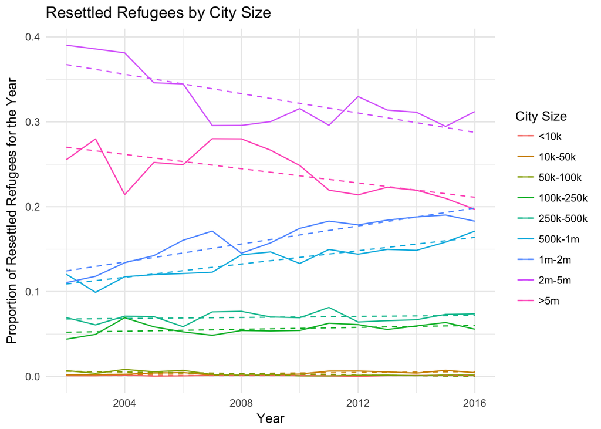

```r
yearlyresettled %>% filter(!is.na(citygroup)) %>% group_by(year, citygroup) %>% summarize(prop=sum(count)/yeartotal[1]) %>% ggplot(aes(y=prop, x=as.numeric(as.character(year)), group=citygroup, color=citygroup))+geom_line()+geom_smooth(method='lm',formula=y~x, se=FALSE, size=.5, linetype="dashed")+labs(title="Resettled Refugees by City Size", x="Year",y="Proportion of Resettled Refugees for the Year")+scale_color_discrete(name="City Size")+theme_minimal()
```

This makes it clearer that the shift is from the really large cities to the next tier, 500,000-2 million. Smaller cities may be trending up, but because they take fewer refugees total, the impact isn’t as great. Let’s do the above with a chart style that is more appropriate for the fact that we’re plotting proportions:

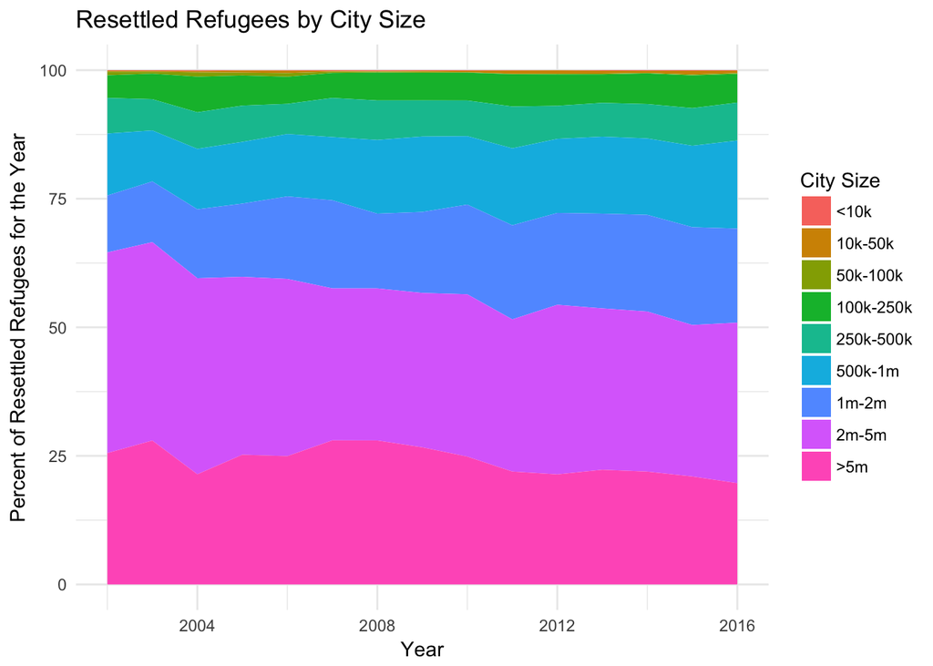

```r
yearlyresettled %>% filter(!is.na(citygroup)) %>% group_by(year, citygroup) %>% summarize(prop=sum(count)/yeartotal[1]) %>% ggplot(aes(y=prop, x=as.numeric(as.character(year)), group=(citygroup), fill=(citygroup)))+geom_area()+labs(title="Resettled Refugees by City Size", x="Year",y="Percent of Resettled Refugees for the Year")+scale_fill_discrete(name="City Size")+scale_y_continuous(labels=function(x){as.integer(x*100)})+theme_minimal()
```

This one makes it harder to read the trends.

# Population Data Note

Instead of just using 2015 population data, we can look at trends over time, but this is really only manageable at the country level, not the city or metro level. The metro definitions change in 2009 and 2013, so this severely limits the trends that can be picked up at that level. Some trends are possible for individual case studies, because the changes in the metro area definitions can be examined, but at the aggregate level, this doesn’t work well.

# Current Economic Data

Try to add in current economic data from the Bureau of Economic Analysis: https://www.bea.gov/itable/ (US Dept of Commerce). Units are millions of chained (?) 2009 dollars. Only available for metro areas.

Step 1: try to match up:

```r
bea<-head(read.csv("data/metrogdp.csv", stringsAsFactors = FALSE, skip=4), -4)
names(bea)[3:ncol(bea)]<-paste0("y",str_sub(names(bea)[3:ncol(bea)], 2))
bea$cleanedarea<-str_replace(bea$Area, ' \\(.+\\)', '')
beapercap<-head(read.csv("data/metrogdppercap.csv", stringsAsFactors = FALSE, skip=4), -4)
names(beapercap)[3:ncol(beapercap)]<-paste0("y",str_sub(names(beapercap)[3:ncol(beapercap)],2))
beapercap$cleanedarea<-str_replace(beapercap$Area, ' \\(.+\\)', '')
```

```r
resettledgdp<-merge(totalresettled, bea, all.x=TRUE, by.x=c("geoid"), by.y=c("Fips"))
```

This provides data for all of the metro areas with population above ~220,000 except the 2 in Puerto Rico, and some areas smaller that than (about 50 of them). This covers over 98% of resettled refugees:

```r
sum(resettledgdp$count[!is.na(resettledgdp$y2014.2015)], na.rm=TRUE)/sum(resettledgdp$count, na.rm=TRUE)
```

```
## [1] 0.9852128
```

The national GDP annual % change for 2015 was 3.8%

Let’s look at refugee resettlement in reference to that. Current economic conditions of places refugees were initially resettled:

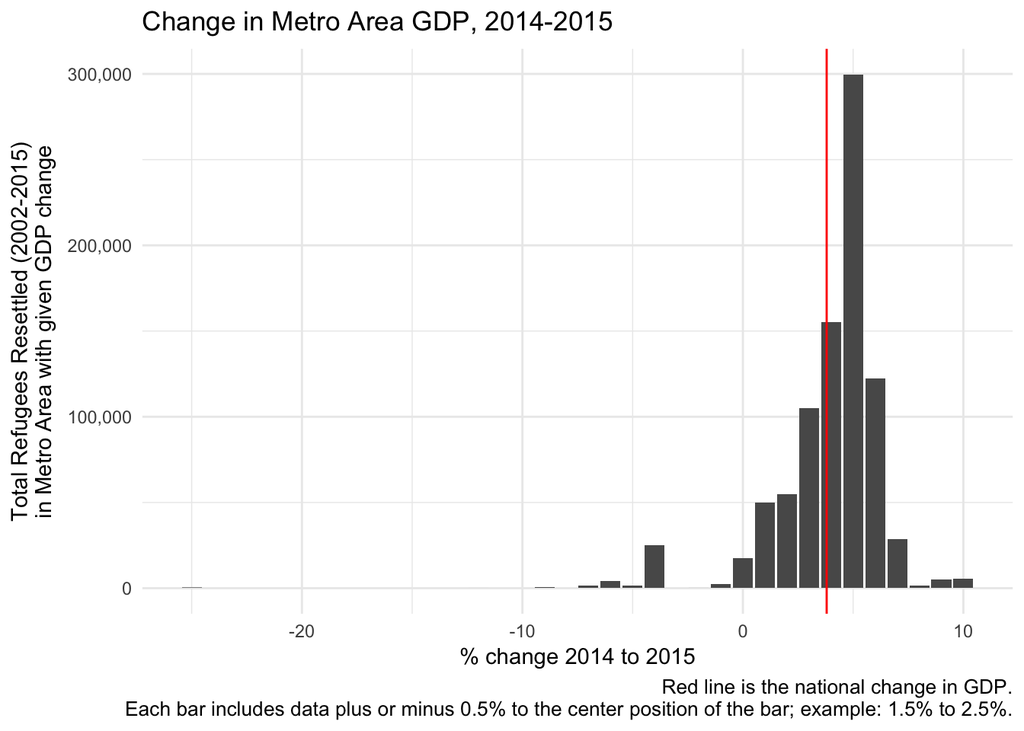

```r
resettledgdp$changecat<-as.numeric(as.character(cut(resettledgdp$y2014.2015, breaks=seq(-25.5, 10.5, by=1), labels=-25:10)))
filter(resettledgdp, !is.na(changecat)) %>% group_by(changecat) %>% summarize(refcount=sum(count)) %>% ggplot(aes(x=changecat, y=refcount))+geom_bar(stat="identity")+labs(title="Change in Metro Area GDP, 2014-2015", x="% change 2014 to 2015", y="Total Refugees Resettled (2002-2015)\nin Metro Area with given GDP change", caption="Red line is the national change in GDP.\nEach bar includes data plus or minus 0.5% to the center position of the bar; example: 1.5% to 2.5%.")+geom_vline(xintercept=3.8, color="red")+
  scale_y_continuous(labels=comma)+
  theme_minimal()
```

Not sure how useful this is – would probably need to look at longer term trends of economic growth or decline.

Look at per capita GDP as a measure of the wealth of the area that refugees were resettled in? National level is 52896

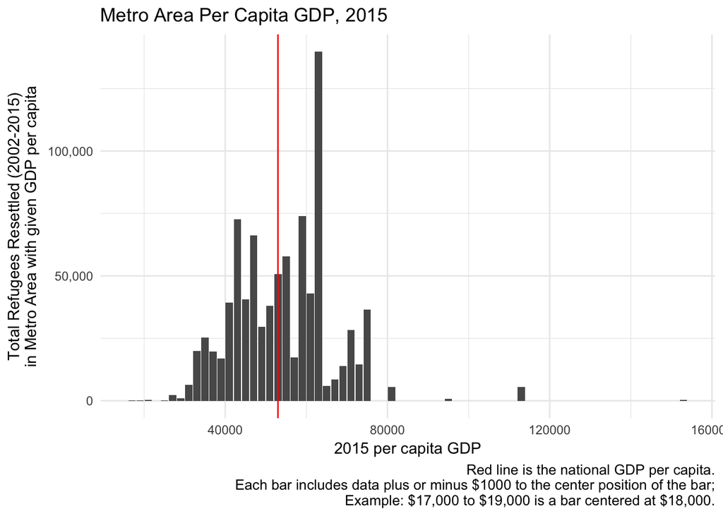

```r
resettledgdp<-merge(resettledgdp, beapercap, all.x=TRUE, by.x=c("geoid"), by.y=c("Fips"))
resettledgdp$percapcat<-as.numeric(as.character(cut(resettledgdp$y2015, breaks=seq(16000,154000, 2000), labels=seq(17000,153000, 2000))))
filter(resettledgdp, !is.na(percapcat)) %>% group_by(percapcat) %>% summarize(refcount=sum(count)) %>% ggplot(aes(x=percapcat, y=refcount))+geom_bar(stat="identity")+labs(title="Metro Area Per Capita GDP, 2015", x="2015 per capita GDP", y="Total Refugees Resettled (2002-2015)\nin Metro Area with given GDP per capita", caption="Red line is the national GDP per capita.\nEach bar includes data plus or minus $1000 to the center position of the bar;\nExample: $17,000 to $19,000 is a bar centered at $18,000.")+geom_vline(xintercept=53000, color="red")+
  scale_y_continuous(labels=comma)+
  theme_minimal()
```

Looks like a pretty even distribution of refugees to all different types of areas.

Let’s look at just the smaller cities, again, only current GDP per capita:

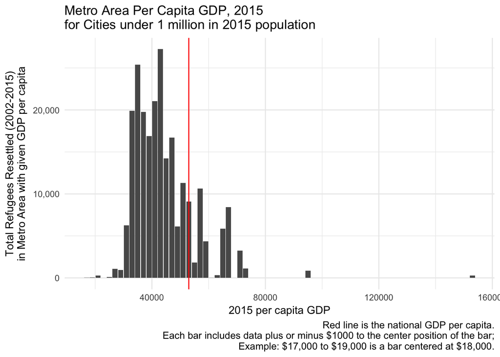

```r
filter(resettledgdp, !is.na(percapcat)&population2015<=1000000) %>% group_by(percapcat) %>% summarize(refcount=sum(count)) %>% ggplot(aes(x=percapcat, y=refcount))+geom_bar(stat="identity")+labs(title="Metro Area Per Capita GDP, 2015\nfor Cities under 1 million in 2015 population", x="2015 per capita GDP", y="Total Refugees Resettled (2002-2015)\nin Metro Area with given GDP per capita", caption="Red line is the national GDP per capita.\nEach bar includes data plus or minus $1000 to the center position of the bar;\nExample: $17,000 to $19,000 is a bar centered at $18,000.")+geom_vline(xintercept=53000, color="red")+
  scale_y_continuous(labels=comma)+
  theme_minimal()
```

Unsurprisingly, smaller areas usually have lower GDP per capita. Here’s the overall relationship for reference, for cities in our data:

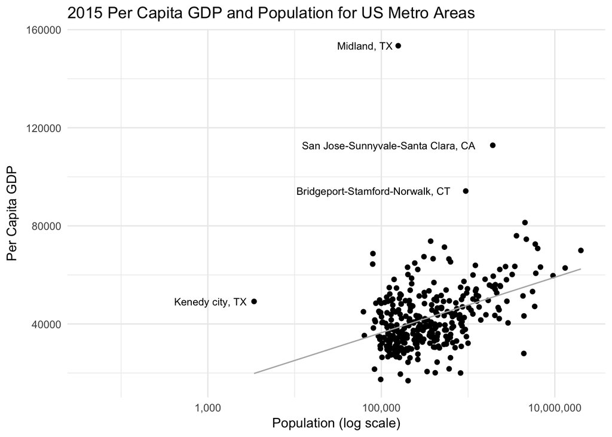

```r
resettledgdp %>% select(place, population2015, y2015) %>% ggplot(aes(x=population2015, y=y2015))+geom_point()+scale_x_log10(labels=comma)+labs(title="2015 Per Capita GDP and Population for US Metro Areas", x="Population (log scale)", y="Per Capita GDP")+geom_smooth(method='lm',formula=y~x, se=FALSE, size=.5, color="gray70")+geom_text(aes(label=ifelse(y2015>90000|population2015<10000,place,'')),hjust=1.1,vjust=0.5, size=3)+theme_minimal()
```

# Economic trajectories

Let’s look at the GDP trajectory over time for some of the small-mid sized cities (100,000-500,000 in population) that had the most refugees, and that we have GDP data for. We’ll plot GDP per capita

```r
resettledgdp %>% filter(population2015>100000 & population2015<500000 & !is.na(y2015)) %>% arrange(desc(count)) %>% select(place, count, population2015, y2015) %>% datatable()
```

|  | place | count | population2015 | y2015 |
| --- | --- | --- | --- | --- |
| 1 | Erie, PA | 6935 | 279858 | 34914 |
| 2 | Lansing-East Lansing, MI | 6862 | 468737 | 39644 |
| 3 | Utica-Rome, NY | 5953 | 297592 | 32607 |
| 4 | Amarillo, TX | 5571 | 259216 | 41460 |
| 5 | Sioux Falls, SD | 5018 | 242731 | 64834 |
| 6 | Fargo, ND-MN | 4345 | 223379 | 58644 |
| 7 | Bowling Green, KY | 4178 | 164245 | 34805 |
| 8 | Burlington-South Burlington, VT | 3977 | 215081 | 53759 |
| 9 | Fort Wayne, IN | 3711 | 424579 | 44912 |
| 10 | Rockford, IL | 3331 | 344290 | 39071 |

[output cut: 204 more lines]

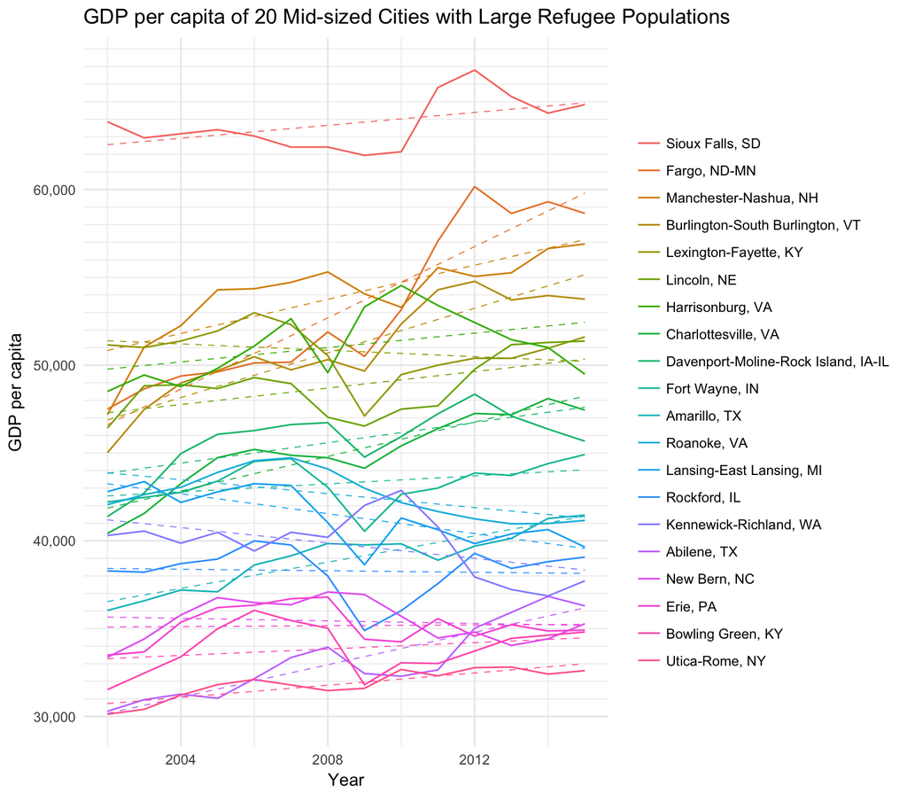

```r
resettledgdp %>% filter(population2015>100000 & population2015<500000 & !is.na(y2015)) %>%
  arrange(desc(count)) %>% head(20) %>%
  mutate(place2=factor(place, levels=place[order(y2015, decreasing=TRUE)])) %>%
  gather_("year", "gdppc", paste0("y",2002:2015)) %>%
  mutate(year=as.numeric(str_sub(year, 2))) %>%
  ggplot(aes(x=year, y=gdppc, group=place2, color=place2))+
  scale_y_continuous(minor_breaks = seq(30000,70000,1000), labels=comma)+
  geom_line()+
  scale_color_discrete(name="")+
  geom_smooth(method='lm',formula=y~x, se=FALSE, size=.3, linetype="dashed")+
  labs(title="GDP per capita of 20 Mid-sized Cities with Large Refugee Populations", x="Year", y="GDP per capita")+
  theme_minimal()
```

Let’s split about the above by how much gdp per capita is increasing (or not):

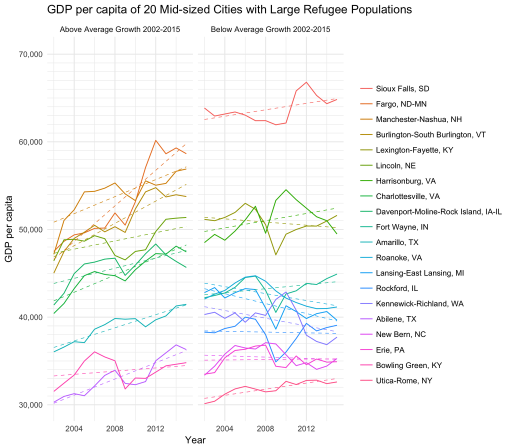

```r
resettledgdp %>% filter(population2015>100000 & population2015<500000 & !is.na(y2015)) %>%
  arrange(desc(count)) %>% head(20) %>%
  mutate(place2=factor(place, levels=place[order(y2015, decreasing=TRUE)]),
         growth=factor((y2015-y2002)/y2002 >.094, levels=c(TRUE, FALSE), labels=c("Above Average Growth 2002-2015","Below Average Growth 2002-2015"))) %>%
  gather_("year", "gdppc", paste0("y",2002:2015)) %>%
  mutate(year=as.numeric(str_sub(year, 2))) %>%
  ggplot(aes(x=year, y=gdppc, group=place2, color=place2))+
  scale_y_continuous(minor_breaks = seq(30000,70000,1000), labels=comma, limits = c(NA, 70000))+
  geom_line()+
  facet_grid(.~growth)+
  scale_color_discrete(name="")+
  geom_smooth(method='lm',formula=y~x, se=FALSE, size=.3, linetype="dashed")+
  labs(title="GDP per capita of 20 Mid-sized Cities with Large Refugee Populations", x="Year", y="GDP per capita")+
  theme_minimal()
```

The cutoff used above is whether growth between 2002 and 2015 was more or less than the national rate of 9.4%. As expected, it’s about half and half compared to the national average. Refugees went to a mix of different economies.